# Project Report for Practical Machine Learning

Victor Li

Friday, July 24, 2015

# Overview

Using devices such as Jawbone Up, Nike FuelBand, and Fitbit it is now possible to collect a large amount of data about personal activity relatively inexpensively. These type of devices are part of the quantified self movement - a group of enthusiasts who take measurements about themselves regularly to improve their health, to find patterns in their behavior, or because they are tech geeks. One thing that people regularly do is quantify how much of a particular activity they do, but they rarely quantify how well they do it.

In this project, our goal is to use data from accelerometers on the belt, forearm, arm, and dumbell of 6 participants to predict the manner in which they did the exercise, which is depicted by the “classe” column in given data.

# Prepare Data

## Download Data

The training data for this project are available here:

https://d396qusza40orc.cloudfront.net/predmachlearn/pml-training.csv

The test data are available here:

https://d396qusza40orc.cloudfront.net/predmachlearn/pml-testing.csv

For some reason “download.file” doesn’t work with “https” scheme when running in Knitr, so we downloaded both data file ahead and then run Knitr to generate this report.

```r
library(caret)
```

```r
# Download PML train and test data
trainFile <- "pml-training.csv"
testFile <- "pml-testing.csv"
download.file("https://d396qusza40orc.cloudfront.net/predmachlearn/pml-training.csv", destfile = trainFile, method = "auto")
download.file("https://d396qusza40orc.cloudfront.net/predmachlearn/pml-testing.csv", destfile = testFile, method = "auto")
```

```r
# Load data to memory
trainRawData <- read.csv("pml-training.csv")
testRawData <- read.csv("pml-testing.csv")
```

## Examine Data Quality

First we quick check the dimension of input data. As shown below, the train data has 19622 observations with 160 columns, while the test data has 20 observations and 160 columns.

```r
dim(trainRawData)
```

```
## [1] 19622   160
```

```r
dim(testRawData)
```

```
## [1]  20 160
```

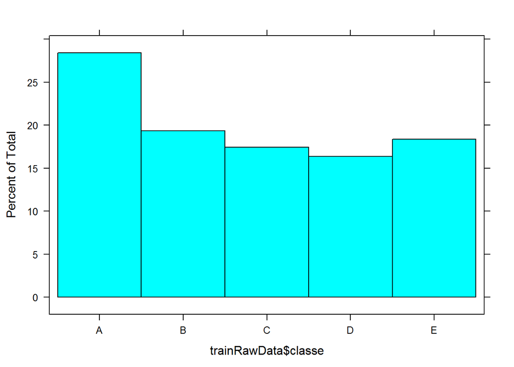

```r
# Distribution of train data per Classe
histogram(trainRawData$classe)
```

## Data Cleanup

However, when we browse the train data, we noticed there are couple of issues which may harm model training:

- There are lots of NA data which are not useless to train a model
- Non numeric columns are not useful here as well
- Columns like user name, timestamp are not meaningful to exercise manner

So we clean up these columns first. However the column “classe” should be kept because we need build model to predict it.

We cleaned both train and test data in same way:

```r
# Clean data
CleanRawData <- function(rawData)
{
    # Remove column which has too many NA values (more than 30%)
    data <- rawData[, colSums(is.na(rawData)) / nrow(rawData) < 0.30]

    # Remove column which are not likely related to classe
    toRemove <- grepl("^(X|user_name)$|_(timestamp|window)", names(data))
    data <- data[, !toRemove]

    # Remove non-numeric columns, but keeping classe column
    classe <- data$classe
    data <- data[, sapply(data, is.numeric)]
    data$classe <- classe

    return(data)
}

trainData <- CleanRawData(trainRawData)
testData <- CleanRawData(testRawData)
```

Now we can see the number of columns drop to 53 for both data:

```r
dim(trainData)
```

```
## [1] 19622    53
```

```r
dim(testData)
```

```
## [1] 20 53
```

# Build Model with Train Data

Now we can go ahead to train the model with given train data. To help cross validation, we split the given data to 2 parts:

- Train data: 60%, used to build model
- Test data: 40%, used to validate the model for accuracy

```r
# Partition data for cross validation
set.seed(12345)
trainIndex <- createDataPartition(trainData$classe, p=0.60, list=FALSE)
modelTrainData <- trainData[trainIndex, ]
modelTestData <- trainData[-trainIndex, ]
```

There are many models availabe for machine learning. In this project we simply choose 2 typical models to build:

- Decision Tree model
- Random Forest model

Then based on their accuracy of predicting test data, we choose the better one as our final model.

## Decision Tree

First we use train data to build the decision tree model:

```r
# Build model with train data: Decision Tree
modelDT <- train(classe ~ ., data = modelTrainData, method = "rpart")
modelDT
```

```
## CART
##
## 11776 samples
##    52 predictor
##     5 classes: 'A', 'B', 'C', 'D', 'E'
##
## No pre-processing
## Resampling: Bootstrapped (25 reps)
##
## Summary of sample sizes: 11776, 11776, 11776, 11776, 11776, 11776, ...
##
## Resampling results across tuning parameters:
##
##   cp          Accuracy   Kappa       Accuracy SD  Kappa SD
##   0.03909587  0.4938233  0.33851680  0.07172111   0.11893424
##   0.03946369  0.4912647  0.33459350  0.07058932   0.11695692
##   0.11449929  0.3327254  0.07362743  0.03945600   0.06140008
##
## Accuracy was used to select the optimal model using  the largest value.
## The final value used for the model was cp = 0.03909587.
```

Then apply this model to the test data and predict the exercise manner:

```r
# Validate model with test data
predictDT <- predict(modelDT, modelTestData)
confusionMatrix(modelTestData$classe, predictDT)
```

```
## Confusion Matrix and Statistics
##
##           Reference
## Prediction    A    B    C    D    E
##          A 1357    3  693  171    8
##          B  229  259  725  305    0
##          C   38   28  819  483    0
##          D   66    8  389  823    0
##          E   15   10  557  200  660
##
## Overall Statistics
##
##                Accuracy : 0.4994
##                  95% CI : (0.4882, 0.5105)
##     No Information Rate : 0.4057
##     P-Value [Acc > NIR] : < 2.2e-16
##
##                   Kappa : 0.3764
##  Mcnemar's Test P-Value : < 2.2e-16
##
## Statistics by Class:
##
##                      Class: A Class: B Class: C Class: D Class: E
## Sensitivity            0.7959  0.84091   0.2573   0.4152  0.98802
## Specificity            0.8575  0.83298   0.8823   0.9210  0.89106
## Pos Pred Value         0.6080  0.17062   0.5987   0.6400  0.45770
## Neg Pred Value         0.9380  0.99226   0.6351   0.8233  0.99875
## Prevalence             0.2173  0.03926   0.4057   0.2526  0.08514
## Detection Rate         0.1730  0.03301   0.1044   0.1049  0.08412
## Detection Prevalence   0.2845  0.19347   0.1744   0.1639  0.18379
## Balanced Accuracy      0.8267  0.83694   0.5698   0.6681  0.93954
```

As we can see, the accuracy for prediction is quite low: only around 50%.

## Random Forest

To build the Random Forest model with train data, we choose 4 round cross validation to find optimal model:

```r
# Build model with train data: Random Forest with 4 round cross validation
controlRF <- trainControl(method = "cv", number = 4)
modelRF <- train(classe ~ ., data = modelTrainData, method = "rf", trControl = controlRF)
modelRF
```

```
## Random Forest
##
## 11776 samples
##    52 predictor
##     5 classes: 'A', 'B', 'C', 'D', 'E'
##
## No pre-processing
## Resampling: Cross-Validated (4 fold)
##
## Summary of sample sizes: 8833, 8833, 8831, 8831
##
## Resampling results across tuning parameters:
##
##   mtry  Accuracy   Kappa      Accuracy SD  Kappa SD
##    2    0.9877722  0.9845302  0.002627848  0.003327668
##   27    0.9887063  0.9857132  0.001822453  0.002306235
##   52    0.9848850  0.9808793  0.002291644  0.002900637
##
## Accuracy was used to select the optimal model using  the largest value.
## The final value used for the model was mtry = 27.
```

Then predict the test data with result model:

```r
# Validate model with test data
predictRF <- predict(modelRF, modelTestData)
confusionMatrix(modelTestData$classe, predictRF)
```

```
## Confusion Matrix and Statistics
##
##           Reference
## Prediction    A    B    C    D    E
##          A 2228    4    0    0    0
##          B   10 1502    6    0    0
##          C    0    6 1358    4    0
##          D    0    0   21 1263    2
##          E    0    1    3    5 1433
##
## Overall Statistics
##
##                Accuracy : 0.9921
##                  95% CI : (0.9899, 0.9939)
##     No Information Rate : 0.2852
##     P-Value [Acc > NIR] : < 2.2e-16
##
##                   Kappa : 0.99
##  Mcnemar's Test P-Value : NA
##
## Statistics by Class:
##
##                      Class: A Class: B Class: C Class: D Class: E
## Sensitivity            0.9955   0.9927   0.9784   0.9929   0.9986
## Specificity            0.9993   0.9975   0.9985   0.9965   0.9986
## Pos Pred Value         0.9982   0.9895   0.9927   0.9821   0.9938
## Neg Pred Value         0.9982   0.9983   0.9954   0.9986   0.9997
## Prevalence             0.2852   0.1928   0.1769   0.1621   0.1829
## Detection Rate         0.2840   0.1914   0.1731   0.1610   0.1826
## Detection Prevalence   0.2845   0.1935   0.1744   0.1639   0.1838
## Balanced Accuracy      0.9974   0.9951   0.9884   0.9947   0.9986
```

The accuracy shown here is much better and almost close to 100%. We will use this model to predict the final test data as required by this project.

# Predict Test Data

Now we apply the generated Random Forest model to predict our final test data:

```r
# Random Forest model wins!
# Predict the provided test data
predict(modelRF, testData)
```

```
##  [1] B A B A A E D B A A B C B A E E A B B B
## Levels: A B C D E
```

The results are submitted to Coursera and passed 100%.